# Risk Factor Analysis

## Outcome Variable

**Outcome Variable:** stunted

## Predictor Variables

**Intervention Variable:** fage

**Adjustment Set:**

- arm
- W_mage
- meducyrs
- feducyrs
- W_mhtcm
- W_mwtkg
- W_mbmi
- W_fhtcm
- single
- brthmon
- delta_W_mage
- delta_meducyrs
- delta_feducyrs
- delta_W_mhtcm
- delta_W_mwtkg
- delta_W_mbmi
- delta_W_fhtcm
- delta_single
- delta_brthmon

## Stratifying Variables

The analysis was stratified on these variable(s):

- agecat
- studyid
- country

## Data Summary

| agecat | studyid | country | fage | stunted | n_cell | n |
| --- | --- | --- | --- | --- | --- | --- |
| Birth | COHORTS | GUATEMALA | >=38 | 0 | 230 | 823 |
| Birth | COHORTS | GUATEMALA | >=38 | 1 | 15 | 823 |
| Birth | COHORTS | GUATEMALA | <32 | 0 | 358 | 823 |
| Birth | COHORTS | GUATEMALA | <32 | 1 | 22 | 823 |
| Birth | COHORTS | GUATEMALA | [32-38) | 0 | 185 | 823 |
| Birth | COHORTS | GUATEMALA | [32-38) | 1 | 13 | 823 |
| Birth | COHORTS | PHILIPPINES | >=38 | 0 | 304 | 2944 |
| Birth | COHORTS | PHILIPPINES | >=38 | 1 | 24 | 2944 |
| Birth | COHORTS | PHILIPPINES | <32 | 0 | 1954 | 2944 |
| Birth | COHORTS | PHILIPPINES | <32 | 1 | 125 | 2944 |
| Birth | COHORTS | PHILIPPINES | [32-38) | 0 | 506 | 2944 |
| Birth | COHORTS | PHILIPPINES | [32-38) | 1 | 31 | 2944 |
| Birth | MAL-ED | BANGLADESH | >=38 | 0 | 52 | 133 |
| Birth | MAL-ED | BANGLADESH | >=38 | 1 | 11 | 133 |
| Birth | MAL-ED | BANGLADESH | <32 | 0 | 21 | 133 |
| Birth | MAL-ED | BANGLADESH | <32 | 1 | 4 | 133 |
| Birth | MAL-ED | BANGLADESH | [32-38) | 0 | 40 | 133 |
| Birth | MAL-ED | BANGLADESH | [32-38) | 1 | 5 | 133 |
| Birth | MAL-ED | BRAZIL | >=38 | 0 | 4 | 18 |
| Birth | MAL-ED | BRAZIL | >=38 | 1 | 2 | 18 |
| Birth | MAL-ED | BRAZIL | <32 | 0 | 1 | 18 |
| Birth | MAL-ED | BRAZIL | <32 | 1 | 0 | 18 |
| Birth | MAL-ED | BRAZIL | [32-38) | 0 | 9 | 18 |
| Birth | MAL-ED | BRAZIL | [32-38) | 1 | 2 | 18 |
| Birth | MAL-ED | INDIA | >=38 | 0 | 6 | 27 |
| Birth | MAL-ED | INDIA | >=38 | 1 | 1 | 27 |
| Birth | MAL-ED | INDIA | <32 | 0 | 5 | 27 |
| Birth | MAL-ED | INDIA | <32 | 1 | 4 | 27 |
| Birth | MAL-ED | INDIA | [32-38) | 0 | 9 | 27 |
| Birth | MAL-ED | INDIA | [32-38) | 1 | 2 | 27 |

[output cut: 180 more lines]

The following strata were considered:

- agecat: 24 months, studyid: COHORTS, country: GUATEMALA
- agecat: 24 months, studyid: COHORTS, country: PHILIPPINES
- agecat: 24 months, studyid: LCNI-5, country: MALAWI
- agecat: 24 months, studyid: MAL-ED, country: BANGLADESH
- agecat: 24 months, studyid: MAL-ED, country: BRAZIL
- agecat: 24 months, studyid: MAL-ED, country: INDIA
- agecat: 24 months, studyid: MAL-ED, country: NEPAL
- agecat: 24 months, studyid: MAL-ED, country: PERU
- agecat: 24 months, studyid: MAL-ED, country: SOUTH AFRICA
- agecat: 24 months, studyid: MAL-ED, country: TANZANIA, UNITED REPUBLIC OF
- agecat: 24 months, studyid: PROBIT, country: BELARUS
- agecat: 6 months, studyid: COHORTS, country: GUATEMALA
- agecat: 6 months, studyid: COHORTS, country: PHILIPPINES
- agecat: 6 months, studyid: LCNI-5, country: MALAWI
- agecat: 6 months, studyid: MAL-ED, country: BANGLADESH
- agecat: 6 months, studyid: MAL-ED, country: BRAZIL
- agecat: 6 months, studyid: MAL-ED, country: INDIA
- agecat: 6 months, studyid: MAL-ED, country: NEPAL
- agecat: 6 months, studyid: MAL-ED, country: PERU
- agecat: 6 months, studyid: MAL-ED, country: SOUTH AFRICA
- agecat: 6 months, studyid: MAL-ED, country: TANZANIA, UNITED REPUBLIC OF
- agecat: 6 months, studyid: PROBIT, country: BELARUS
- agecat: 6 months, studyid: SAS-CompFeed, country: INDIA
- agecat: 6 months, studyid: SAS-FoodSuppl, country: INDIA
- agecat: Birth, studyid: COHORTS, country: GUATEMALA
- agecat: Birth, studyid: COHORTS, country: PHILIPPINES
- agecat: Birth, studyid: MAL-ED, country: BANGLADESH
- agecat: Birth, studyid: MAL-ED, country: BRAZIL
- agecat: Birth, studyid: MAL-ED, country: INDIA
- agecat: Birth, studyid: MAL-ED, country: NEPAL
- agecat: Birth, studyid: MAL-ED, country: PERU
- agecat: Birth, studyid: MAL-ED, country: SOUTH AFRICA
- agecat: Birth, studyid: MAL-ED, country: TANZANIA, UNITED REPUBLIC OF
- agecat: Birth, studyid: PROBIT, country: BELARUS
- agecat: Birth, studyid: SAS-CompFeed, country: INDIA

### Dropped Strata

Some strata were dropped due to rare outcomes:

- agecat: Birth, studyid: MAL-ED, country: BANGLADESH
- agecat: Birth, studyid: MAL-ED, country: BRAZIL
- agecat: Birth, studyid: MAL-ED, country: INDIA
- agecat: Birth, studyid: MAL-ED, country: NEPAL
- agecat: Birth, studyid: MAL-ED, country: PERU
- agecat: Birth, studyid: MAL-ED, country: SOUTH AFRICA
- agecat: Birth, studyid: MAL-ED, country: TANZANIA, UNITED REPUBLIC OF
- agecat: Birth, studyid: PROBIT, country: BELARUS
- agecat: 6 months, studyid: MAL-ED, country: BRAZIL
- agecat: 6 months, studyid: MAL-ED, country: NEPAL
- agecat: 6 months, studyid: MAL-ED, country: PERU
- agecat: 6 months, studyid: MAL-ED, country: SOUTH AFRICA
- agecat: 24 months, studyid: LCNI-5, country: MALAWI
- agecat: 24 months, studyid: MAL-ED, country: BRAZIL
- agecat: 24 months, studyid: MAL-ED, country: NEPAL
- agecat: 24 months, studyid: MAL-ED, country: SOUTH AFRICA
- agecat: 24 months, studyid: MAL-ED, country: TANZANIA, UNITED REPUBLIC OF

## Methods Detail

We’re interested in the causal parameters $E[Y_a]$ for all values of $a \in \mathcal{A}$. These parameters represent the mean outcome if, possibly contrary to fact, we intervened to set all units to have $A=a$. Under the randomization and positivity assumptions, these are identified by the statistical parameters $\psi_a=E_W[E_{Y|A,W}(Y|A=a,W)]$. In addition, we’re interested in the mean of $Y$, $E[Y]$ under no intervention (the observed mean). We will estimate these parameters by using SuperLearner to fit the relevant likelihood factors – $E_{Y|A,W}(Y|A=a,W)$ and $p(A=a|W)$, and then updating our likelihood fit using a joint TMLE.

For unadjusted analyses ($W=\{\}$), initial likelihoods were estimated using Lrnr_glm to estimate the simple $E(Y|A)$ and Lrnr_mean to estimate $p(A)$. For adjusted analyses, a small library containing Lrnr_glmnet, Lrnr_xgboost, and Lrnr_mean was used.

Having estimated these parameters, we will then use the delta method to estimate relative risks and attributable risks relative to a prespecified baseline level of $A$.

# Results Detail

## Results Plots

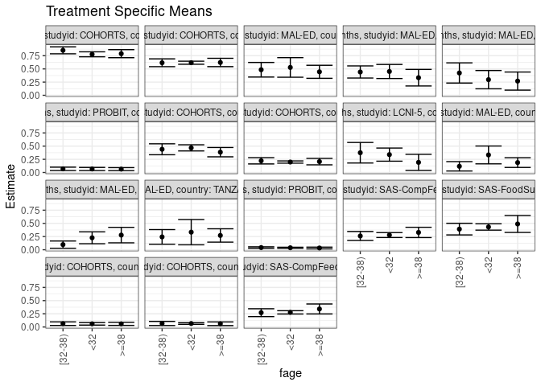

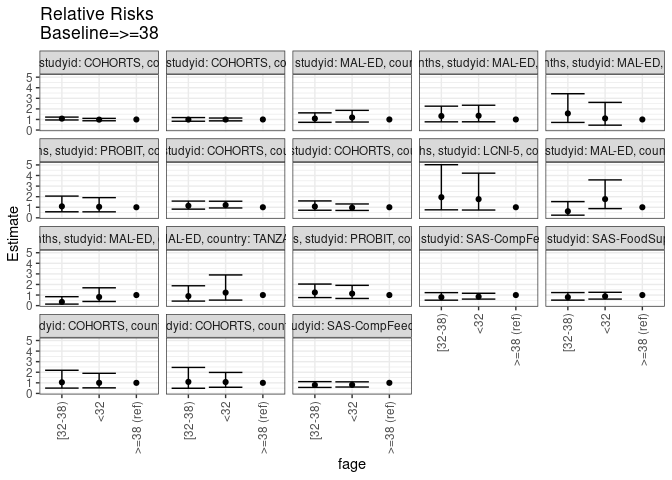

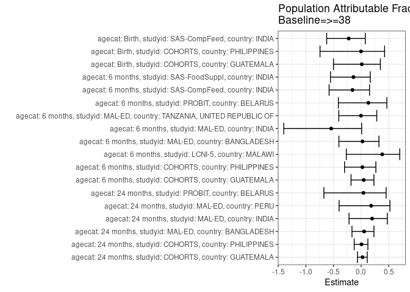

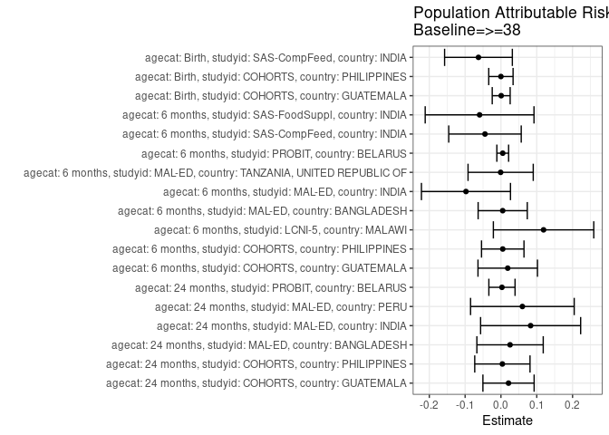

## Results Table

### Parameter: TSM

| agecat | studyid | country | intervention_level | baseline_level | estimate | ci_lower | ci_upper |
| --- | --- | --- | --- | --- | --- | --- | --- |
| Birth | COHORTS | GUATEMALA | >=38 | NA | 0.0600476 | 0.0301795 | 0.0899158 |
| Birth | COHORTS | GUATEMALA | <32 | NA | 0.0600249 | 0.0355629 | 0.0844868 |
| Birth | COHORTS | GUATEMALA | [32-38) | NA | 0.0630554 | 0.0289905 | 0.0971204 |
| Birth | COHORTS | PHILIPPINES | >=38 | NA | 0.0612156 | 0.0265443 | 0.0958869 |
| Birth | COHORTS | PHILIPPINES | <32 | NA | 0.0658048 | 0.0503431 | 0.0812666 |
| Birth | COHORTS | PHILIPPINES | [32-38) | NA | 0.0668684 | 0.0281829 | 0.1055540 |
| Birth | SAS-CompFeed | INDIA | >=38 | NA | 0.3413555 | 0.2468262 | 0.4358847 |
| Birth | SAS-CompFeed | INDIA | <32 | NA | 0.2772130 | 0.2460633 | 0.3083627 |
| Birth | SAS-CompFeed | INDIA | [32-38) | NA | 0.2711692 | 0.1967541 | 0.3455842 |
| 6 months | COHORTS | GUATEMALA | >=38 | NA | 0.3857937 | 0.2975110 | 0.4740765 |
| 6 months | COHORTS | GUATEMALA | <32 | NA | 0.4670377 | 0.4085463 | 0.5255291 |
| 6 months | COHORTS | GUATEMALA | [32-38) | NA | 0.4405256 | 0.3370103 | 0.5440409 |
| 6 months | COHORTS | PHILIPPINES | >=38 | NA | 0.2068316 | 0.1459211 | 0.2677421 |
| 6 months | COHORTS | PHILIPPINES | <32 | NA | 0.1984098 | 0.1770366 | 0.2197830 |
| 6 months | COHORTS | PHILIPPINES | [32-38) | NA | 0.2219667 | 0.1624251 | 0.2815084 |
| 6 months | LCNI-5 | MALAWI | >=38 | NA | 0.1923077 | 0.0400985 | 0.3445169 |
| 6 months | LCNI-5 | MALAWI | <32 | NA | 0.3392857 | 0.2146903 | 0.4638811 |
| 6 months | LCNI-5 | MALAWI | [32-38) | NA | 0.3750000 | 0.1803939 | 0.5696061 |
| 6 months | MAL-ED | BANGLADESH | >=38 | NA | 0.1884058 | 0.0958310 | 0.2809806 |
| 6 months | MAL-ED | BANGLADESH | <32 | NA | 0.3333333 | 0.1640814 | 0.5025853 |
| 6 months | MAL-ED | BANGLADESH | [32-38) | NA | 0.1176471 | 0.0289259 | 0.2063682 |
| 6 months | MAL-ED | INDIA | >=38 | NA | 0.2777778 | 0.1310089 | 0.4245467 |
| 6 months | MAL-ED | INDIA | <32 | NA | 0.2264151 | 0.1133913 | 0.3394389 |
| 6 months | MAL-ED | INDIA | [32-38) | NA | 0.0972222 | 0.0285774 | 0.1658671 |
| 6 months | MAL-ED | TANZANIA, UNITED REPUBLIC OF | >=38 | NA | 0.2708333 | 0.1444836 | 0.3971831 |
| 6 months | MAL-ED | TANZANIA, UNITED REPUBLIC OF | <32 | NA | 0.3333333 | 0.0935723 | 0.5730944 |
| 6 months | MAL-ED | TANZANIA, UNITED REPUBLIC OF | [32-38) | NA | 0.2432432 | 0.1043030 | 0.3821835 |
| 6 months | PROBIT | BELARUS | >=38 | NA | 0.0330548 | 0.0166469 | 0.0494627 |
| 6 months | PROBIT | BELARUS | <32 | NA | 0.0376381 | 0.0275179 | 0.0477582 |
| 6 months | PROBIT | BELARUS | [32-38) | NA | 0.0411630 | 0.0270580 | 0.0552680 |
| 6 months | SAS-CompFeed | INDIA | >=38 | NA | 0.3281190 | 0.2306023 | 0.4256356 |
| 6 months | SAS-CompFeed | INDIA | <32 | NA | 0.2783919 | 0.2318050 | 0.3249787 |
| 6 months | SAS-CompFeed | INDIA | [32-38) | NA | 0.2608460 | 0.1758061 | 0.3458860 |
| 6 months | SAS-FoodSuppl | INDIA | >=38 | NA | 0.4885612 | 0.3280935 | 0.6490289 |
| 6 months | SAS-FoodSuppl | INDIA | <32 | NA | 0.4316168 | 0.3717594 | 0.4914742 |
| 6 months | SAS-FoodSuppl | INDIA | [32-38) | NA | 0.3910531 | 0.2808034 | 0.5013028 |
| 24 months | COHORTS | GUATEMALA | >=38 | NA | 0.7888243 | 0.7126143 | 0.8650344 |
| 24 months | COHORTS | GUATEMALA | <32 | NA | 0.7766709 | 0.7292949 | 0.8240469 |
| 24 months | COHORTS | GUATEMALA | [32-38) | NA | 0.8522454 | 0.7864992 | 0.9179916 |
| 24 months | COHORTS | PHILIPPINES | >=38 | NA | 0.6218744 | 0.5429715 | 0.7007773 |
| 24 months | COHORTS | PHILIPPINES | <32 | NA | 0.6174941 | 0.5887405 | 0.6462476 |
| 24 months | COHORTS | PHILIPPINES | [32-38) | NA | 0.6161720 | 0.5421360 | 0.6902079 |
| 24 months | MAL-ED | BANGLADESH | >=38 | NA | 0.4447615 | 0.3213273 | 0.5681957 |
| 24 months | MAL-ED | BANGLADESH | <32 | NA | 0.5277751 | 0.3421242 | 0.7134260 |
| 24 months | MAL-ED | BANGLADESH | [32-38) | NA | 0.4839596 | 0.3456306 | 0.6222886 |
| 24 months | MAL-ED | INDIA | >=38 | NA | 0.3332615 | 0.1764118 | 0.4901113 |
| 24 months | MAL-ED | INDIA | <32 | NA | 0.4511452 | 0.3178004 | 0.5844900 |
| 24 months | MAL-ED | INDIA | [32-38) | NA | 0.4415637 | 0.3267947 | 0.5563327 |
| 24 months | MAL-ED | PERU | >=38 | NA | 0.2692308 | 0.0976454 | 0.4408161 |
| 24 months | MAL-ED | PERU | <32 | NA | 0.2962963 | 0.1229596 | 0.4696330 |
| 24 months | MAL-ED | PERU | [32-38) | NA | 0.4230769 | 0.2319613 | 0.6141926 |
| 24 months | PROBIT | BELARUS | >=38 | NA | 0.0641818 | 0.0356621 | 0.0927015 |
| 24 months | PROBIT | BELARUS | <32 | NA | 0.0668027 | 0.0372374 | 0.0963681 |
| 24 months | PROBIT | BELARUS | [32-38) | NA | 0.0695871 | 0.0377322 | 0.1014420 |

### Parameter: E(Y)

| agecat | studyid | country | intervention_level | baseline_level | estimate | ci_lower | ci_upper |
| --- | --- | --- | --- | --- | --- | --- | --- |
| Birth | COHORTS | GUATEMALA | NA | NA | 0.0607533 | 0.0444233 | 0.0770834 |
| Birth | COHORTS | PHILIPPINES | NA | NA | 0.0611413 | 0.0524852 | 0.0697974 |
| Birth | SAS-CompFeed | INDIA | NA | NA | 0.2786229 | 0.2475201 | 0.3097257 |
| 6 months | COHORTS | GUATEMALA | NA | NA | 0.4047363 | 0.3731561 | 0.4363165 |
| 6 months | COHORTS | PHILIPPINES | NA | NA | 0.2118902 | 0.1962516 | 0.2275288 |
| 6 months | LCNI-5 | MALAWI | NA | NA | 0.3113208 | 0.2227550 | 0.3998865 |
| 6 months | MAL-ED | BANGLADESH | NA | NA | 0.1933333 | 0.1299237 | 0.2567430 |
| 6 months | MAL-ED | INDIA | NA | NA | 0.1801242 | 0.1205788 | 0.2396696 |
| 6 months | MAL-ED | TANZANIA, UNITED REPUBLIC OF | NA | NA | 0.2700000 | 0.1825472 | 0.3574528 |
| 6 months | PROBIT | BELARUS | NA | NA | 0.0380714 | 0.0282426 | 0.0479002 |
| 6 months | SAS-CompFeed | INDIA | NA | NA | 0.2835709 | 0.2656121 | 0.3015297 |
| 6 months | SAS-FoodSuppl | INDIA | NA | NA | 0.4289474 | 0.3791199 | 0.4787748 |
| 24 months | COHORTS | GUATEMALA | NA | NA | 0.8099902 | 0.7859147 | 0.8340657 |
| 24 months | COHORTS | PHILIPPINES | NA | NA | 0.6258962 | 0.6064148 | 0.6453777 |
| 24 months | MAL-ED | BANGLADESH | NA | NA | 0.4701987 | 0.3903257 | 0.5500716 |
| 24 months | MAL-ED | INDIA | NA | NA | 0.4161491 | 0.3397719 | 0.4925262 |
| 24 months | MAL-ED | PERU | NA | NA | 0.3291139 | 0.2248346 | 0.4333933 |
| 24 months | PROBIT | BELARUS | NA | NA | 0.0670248 | 0.0408615 | 0.0931881 |

### Parameter: RR

| agecat | studyid | country | intervention_level | baseline_level | estimate | ci_lower | ci_upper |
| --- | --- | --- | --- | --- | --- | --- | --- |
| Birth | COHORTS | GUATEMALA | >=38 | >=38 | 1.0000000 | 1.0000000 | 1.0000000 |
| Birth | COHORTS | GUATEMALA | <32 | >=38 | 0.9996210 | 0.5253870 | 1.9019164 |
| Birth | COHORTS | GUATEMALA | [32-38) | >=38 | 1.0500905 | 0.5037836 | 2.1888169 |
| Birth | COHORTS | PHILIPPINES | >=38 | >=38 | 1.0000000 | 1.0000000 | 1.0000000 |
| Birth | COHORTS | PHILIPPINES | <32 | >=38 | 1.0749682 | 0.5822540 | 1.9846263 |
| Birth | COHORTS | PHILIPPINES | [32-38) | >=38 | 1.0923431 | 0.4861478 | 2.4544254 |
| Birth | SAS-CompFeed | INDIA | >=38 | >=38 | 1.0000000 | 1.0000000 | 1.0000000 |
| Birth | SAS-CompFeed | INDIA | <32 | >=38 | 0.8120947 | 0.6024463 | 1.0946998 |
| Birth | SAS-CompFeed | INDIA | [32-38) | >=38 | 0.7943894 | 0.5675032 | 1.1119841 |
| 6 months | COHORTS | GUATEMALA | >=38 | >=38 | 1.0000000 | 1.0000000 | 1.0000000 |
| 6 months | COHORTS | GUATEMALA | <32 | >=38 | 1.2105891 | 0.9343125 | 1.5685607 |
| 6 months | COHORTS | GUATEMALA | [32-38) | >=38 | 1.1418682 | 0.8232625 | 1.5837754 |
| 6 months | COHORTS | PHILIPPINES | >=38 | >=38 | 1.0000000 | 1.0000000 | 1.0000000 |
| 6 months | COHORTS | PHILIPPINES | <32 | >=38 | 0.9592820 | 0.7013884 | 1.3120004 |
| 6 months | COHORTS | PHILIPPINES | [32-38) | >=38 | 1.0731761 | 0.7206916 | 1.5980580 |
| 6 months | LCNI-5 | MALAWI | >=38 | >=38 | 1.0000000 | 1.0000000 | 1.0000000 |
| 6 months | LCNI-5 | MALAWI | <32 | >=38 | 1.7642857 | 0.7372819 | 4.2218641 |
| 6 months | LCNI-5 | MALAWI | [32-38) | >=38 | 1.9500000 | 0.7568292 | 5.0242509 |
| 6 months | MAL-ED | BANGLADESH | >=38 | >=38 | 1.0000000 | 1.0000000 | 1.0000000 |
| 6 months | MAL-ED | BANGLADESH | <32 | >=38 | 1.7692308 | 0.8728158 | 3.5862980 |
| 6 months | MAL-ED | BANGLADESH | [32-38) | >=38 | 0.6244344 | 0.2538556 | 1.5359844 |
| 6 months | MAL-ED | INDIA | >=38 | >=38 | 1.0000000 | 1.0000000 | 1.0000000 |
| 6 months | MAL-ED | INDIA | <32 | >=38 | 0.8150943 | 0.3940268 | 1.6861258 |
| 6 months | MAL-ED | INDIA | [32-38) | >=38 | 0.3500000 | 0.1449027 | 0.8453946 |
| 6 months | MAL-ED | TANZANIA, UNITED REPUBLIC OF | >=38 | >=38 | 1.0000000 | 1.0000000 | 1.0000000 |
| 6 months | MAL-ED | TANZANIA, UNITED REPUBLIC OF | <32 | >=38 | 1.2307692 | 0.5222084 | 2.9007439 |
| 6 months | MAL-ED | TANZANIA, UNITED REPUBLIC OF | [32-38) | >=38 | 0.8981289 | 0.4295810 | 1.8777263 |
| 6 months | PROBIT | BELARUS | >=38 | >=38 | 1.0000000 | 1.0000000 | 1.0000000 |
| 6 months | PROBIT | BELARUS | <32 | >=38 | 1.1386568 | 0.6762822 | 1.9171571 |
| 6 months | PROBIT | BELARUS | [32-38) | >=38 | 1.2452969 | 0.7608399 | 2.0382271 |
| 6 months | SAS-CompFeed | INDIA | >=38 | >=38 | 1.0000000 | 1.0000000 | 1.0000000 |
| 6 months | SAS-CompFeed | INDIA | <32 | >=38 | 0.8484479 | 0.6159217 | 1.1687588 |
| 6 months | SAS-CompFeed | INDIA | [32-38) | >=38 | 0.7949739 | 0.5149774 | 1.2272064 |
| 6 months | SAS-FoodSuppl | INDIA | >=38 | >=38 | 1.0000000 | 1.0000000 | 1.0000000 |
| 6 months | SAS-FoodSuppl | INDIA | <32 | >=38 | 0.8834448 | 0.6185942 | 1.2616908 |
| 6 months | SAS-FoodSuppl | INDIA | [32-38) | >=38 | 0.8004178 | 0.5191705 | 1.2340238 |
| 24 months | COHORTS | GUATEMALA | >=38 | >=38 | 1.0000000 | 1.0000000 | 1.0000000 |
| 24 months | COHORTS | GUATEMALA | <32 | >=38 | 0.9845930 | 0.8786393 | 1.1033234 |
| 24 months | COHORTS | GUATEMALA | [32-38) | >=38 | 1.0803995 | 0.9550217 | 1.2222373 |
| 24 months | COHORTS | PHILIPPINES | >=38 | >=38 | 1.0000000 | 1.0000000 | 1.0000000 |
| 24 months | COHORTS | PHILIPPINES | <32 | >=38 | 0.9929563 | 0.8680770 | 1.1358005 |
| 24 months | COHORTS | PHILIPPINES | [32-38) | >=38 | 0.9908303 | 0.8322991 | 1.1795575 |
| 24 months | MAL-ED | BANGLADESH | >=38 | >=38 | 1.0000000 | 1.0000000 | 1.0000000 |
| 24 months | MAL-ED | BANGLADESH | <32 | >=38 | 1.1866475 | 0.7572925 | 1.8594299 |
| 24 months | MAL-ED | BANGLADESH | [32-38) | >=38 | 1.0881327 | 0.7286316 | 1.6250088 |
| 24 months | MAL-ED | INDIA | >=38 | >=38 | 1.0000000 | 1.0000000 | 1.0000000 |
| 24 months | MAL-ED | INDIA | <32 | >=38 | 1.3537272 | 0.7805233 | 2.3478829 |
| 24 months | MAL-ED | INDIA | [32-38) | >=38 | 1.3249767 | 0.7771525 | 2.2589689 |
| 24 months | MAL-ED | PERU | >=38 | >=38 | 1.0000000 | 1.0000000 | 1.0000000 |
| 24 months | MAL-ED | PERU | <32 | >=38 | 1.1005291 | 0.4633297 | 2.6140444 |
| 24 months | MAL-ED | PERU | [32-38) | >=38 | 1.5714286 | 0.7195080 | 3.4320507 |
| 24 months | PROBIT | BELARUS | >=38 | >=38 | 1.0000000 | 1.0000000 | 1.0000000 |
| 24 months | PROBIT | BELARUS | <32 | >=38 | 1.0408359 | 0.5675071 | 1.9089441 |
| 24 months | PROBIT | BELARUS | [32-38) | >=38 | 1.0842185 | 0.5721356 | 2.0546346 |

### Parameter: PAR

| agecat | studyid | country | intervention_level | baseline_level | estimate | ci_lower | ci_upper |
| --- | --- | --- | --- | --- | --- | --- | --- |
| Birth | COHORTS | GUATEMALA | >=38 | NA | 0.0007057 | -0.0243275 | 0.0257390 |
| Birth | COHORTS | PHILIPPINES | >=38 | NA | -0.0000743 | -0.0340404 | 0.0338918 |
| Birth | SAS-CompFeed | INDIA | >=38 | NA | -0.0627326 | -0.1573176 | 0.0318524 |
| 6 months | COHORTS | GUATEMALA | >=38 | NA | 0.0189425 | -0.0640800 | 0.1019651 |
| 6 months | COHORTS | PHILIPPINES | >=38 | NA | 0.0050586 | -0.0542245 | 0.0643418 |
| 6 months | LCNI-5 | MALAWI | >=38 | NA | 0.1190131 | -0.0211521 | 0.2591783 |
| 6 months | MAL-ED | BANGLADESH | >=38 | NA | 0.0049275 | -0.0636756 | 0.0735307 |
| 6 months | MAL-ED | INDIA | >=38 | NA | -0.0976536 | -0.2219655 | 0.0266584 |
| 6 months | MAL-ED | TANZANIA, UNITED REPUBLIC OF | >=38 | NA | -0.0008333 | -0.0918639 | 0.0901972 |
| 6 months | PROBIT | BELARUS | >=38 | NA | 0.0050166 | -0.0113914 | 0.0214246 |
| 6 months | SAS-CompFeed | INDIA | >=38 | NA | -0.0445481 | -0.1457432 | 0.0566470 |
| 6 months | SAS-FoodSuppl | INDIA | >=38 | NA | -0.0596138 | -0.2115064 | 0.0922788 |
| 24 months | COHORTS | GUATEMALA | >=38 | NA | 0.0211659 | -0.0503285 | 0.0926602 |
| 24 months | COHORTS | PHILIPPINES | >=38 | NA | 0.0040219 | -0.0731506 | 0.0811943 |
| 24 months | MAL-ED | BANGLADESH | >=38 | NA | 0.0254372 | -0.0672030 | 0.1180773 |
| 24 months | MAL-ED | INDIA | >=38 | NA | 0.0828876 | -0.0568058 | 0.2225809 |
| 24 months | MAL-ED | PERU | >=38 | NA | 0.0598832 | -0.0848113 | 0.2045776 |
| 24 months | PROBIT | BELARUS | >=38 | NA | 0.0028430 | -0.0337048 | 0.0393909 |

### Parameter: PAF

| agecat | studyid | country | intervention_level | baseline_level | estimate | ci_lower | ci_upper |
| --- | --- | --- | --- | --- | --- | --- | --- |
| Birth | COHORTS | GUATEMALA | >=38 | NA | 0.0116162 | -0.4996215 | 0.3485673 |
| Birth | COHORTS | PHILIPPINES | >=38 | NA | -0.0012153 | -0.7438283 | 0.4251543 |
| Birth | SAS-CompFeed | INDIA | >=38 | NA | -0.2251523 | -0.6230222 | 0.0751832 |
| 6 months | COHORTS | GUATEMALA | >=38 | NA | 0.0468022 | -0.1820264 | 0.2313318 |
| 6 months | COHORTS | PHILIPPINES | >=38 | NA | 0.0238739 | -0.3000721 | 0.2671006 |
| 6 months | LCNI-5 | MALAWI | >=38 | NA | 0.3822844 | -0.2683064 | 0.6991479 |
| 6 months | MAL-ED | BANGLADESH | >=38 | NA | 0.0254873 | -0.4024951 | 0.3228674 |
| 6 months | MAL-ED | INDIA | >=38 | NA | -0.5421456 | -1.4008101 | 0.0094123 |
| 6 months | MAL-ED | TANZANIA, UNITED REPUBLIC OF | >=38 | NA | -0.0030864 | -0.4038159 | 0.2832519 |
| 6 months | PROBIT | BELARUS | >=38 | NA | 0.1317687 | -0.4117012 | 0.4660162 |
| 6 months | SAS-CompFeed | INDIA | >=38 | NA | -0.1570968 | -0.5792103 | 0.1521883 |
| 6 months | SAS-FoodSuppl | INDIA | >=38 | NA | -0.1389770 | -0.5545219 | 0.1654871 |
| 24 months | COHORTS | GUATEMALA | >=38 | NA | 0.0261310 | -0.0662908 | 0.1105421 |
| 24 months | COHORTS | PHILIPPINES | >=38 | NA | 0.0064258 | -0.1248423 | 0.1223750 |
| 24 months | MAL-ED | BANGLADESH | >=38 | NA | 0.0540988 | -0.1654191 | 0.2322683 |
| 24 months | MAL-ED | INDIA | >=38 | NA | 0.1991776 | -0.2188934 | 0.4738534 |
| 24 months | MAL-ED | PERU | >=38 | NA | 0.1819527 | -0.3989032 | 0.5216242 |
| 24 months | PROBIT | BELARUS | >=38 | NA | 0.0424175 | -0.6742208 | 0.4523039 |